# Bent Winter 2005

R. G. Cronce

12/19/2019

# Bent Brain Ticklers, Winter 2005

## Problem 1

```
The latest release of the Prime Players
consists of three CDs, each with a
different playing time. Each CD has
four tracks with a total playing time of
not more than one hour. The four tracks
on any of these CDs each last for a different
prime number of minutes. Furthermore,
any combination of three different
tracks on any of these CDs play
for a prime number of minutes. What
are the lengths of the tracks on these
three CDs?

-- Andrew Gibbons in New Scientist
```

Solution: Fairy simple exhaustive search. The primes are 2, 3, … Since the sum of the four primes must not exceed 60 then the largest is 60-(2+3+5) = 50. We can enumerate all the primes up to 50 and look for combinations that meet the requirements above.

```r
library(gmp)
library(gtools)
```

```r
p=(1:50)[isprime(1:50)>0]

# Get all combinations of 4 primes that sum to 60 (or less)
a=combinations(length(p),4,p)
s=apply(a,1,sum)
a=a[s<=60,]

# Find the cases where any combination of three sums to a prime number
s=apply(a,1,function(x) {
    m=combinations(4,3,x);
    all(isprime(apply(m,1,sum)))
    }
    )
a=a[s,]

# Candidate solutions
print(a)
```

```
##      [,1] [,2] [,3] [,4]
## [1,]    5    7   17   19
## [2,]    7   11   13   23
## [3,]    7   13   17   23
```

The only three sets of primes that meet these criteria are:

```
[1,]    5    7   17   19
[2,]    7   11   13   23
[3,]    7   13   17   23
```

## Problem 2

```
The coordinates, in clockwise order,
of the vertices of a heptagon H1 are (0,0),
(2,2), (1,4), (3,6), (3,5), (7,3), and (5,1).
Form a second heptagon H2 by joining
the midpoints of adjacent sides of H1.
Next, form heptagon H3 by joining the
midpoints of the sides of H2. It should
be clear that, because these heptagons
decrease in area, if this process is continued
indefinitely, the heptagon will
ultimately shrink to a point. What are
the coordinates of this point?

-- You Are a Mathematician by David Wells
```

Solution: Let us look at a figure and then make some calculations.

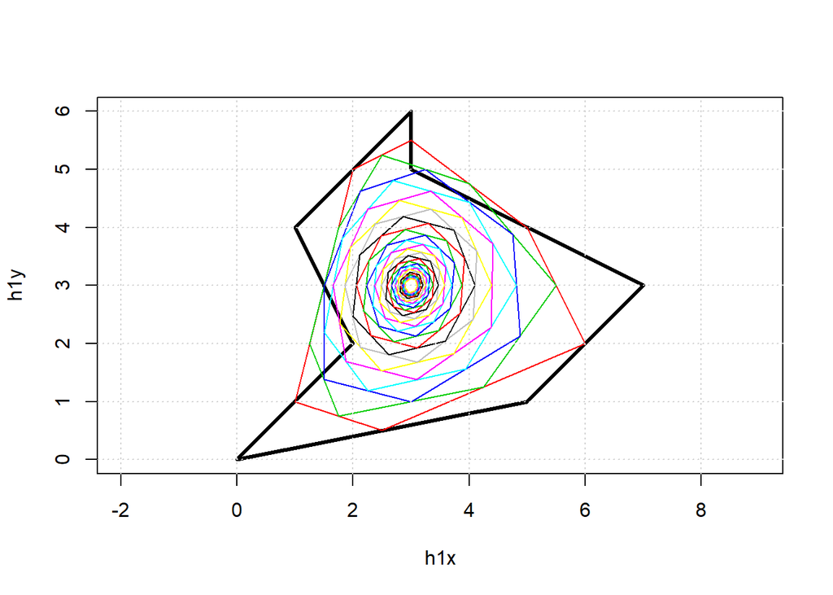

```r
h1x=c(0,2,1,3,3,7,5)
h1y=c(0,2,4,6,5,3,1)
plot(h1x,h1y,type='n',asp=1)
polygon(h1x,h1y,lwd=3)

x=h1x
y=h1y
# p=c('red','blue','green','cyan','black','yellow','orange')
p=palette()
for (i in 1:30) {
    x=c(x,x[1]); hx=(x[1:7]+x[2:8])/2
    y=c(y,y[1]); hy=(y[1:7]+y[2:8])/2
    polygon(hx,hy,border=p[i%%length(p)+1])
    x=hx; y=hy
}
grid()
```

In the limit this shold converge to a point. We can do this numerically or symbolically. Since we are lazy the first attempt will be numerically.

```r
# Given the starting value from H1
h1x=c(0,2,1,3,3,7,5,0)
h1y=c(0,2,4,6,5,3,1,0)

while (T) {
    h2x=(h1x[1:7]+h1x[2:8])/2
    h2y=(h1y[1:7]+h1y[2:8])/2
    xxx = (diff(range(h2x))+diff(range(h2y)))
    if (xxx < 1e-10) { break }
    h1x=c(h2x,h2x[1])
    h1y=c(h2y,h2y[1])
}
print(paste(h2x[1],h2y[1]))
```

```
## [1] "2.99999999999742 3.00000000002439"
```

Numerically the limit appears to by x=3, y=3.

These are the means of the original X,Y coordinates.

The solution calls this the centroid of the figure and demonstrates that the centroid remains unchanged after a round of coordinate conversions so it will eventually be the remaining point.

## Problem 3

```
Two five-person tennis teams, the
Aces and the Bulls, play each other in
the finals of a tournament. The ranking
of the 10 players from most skillful to
least skillful is A1, B1, A2, B2, A3, B3,
A4, B4, A5, and B5. Any player always
beats a player of lesser skill. The finals
consists of five one-on-one matches,
with the winner being the team that
wins three or more matches. If the pair-
ings are determined by pulling names
out of a hat, what is the probability that
the Bulls will win?

--Howard G. McIlvried III, PA Gamma'53
```

Solution: we could try this analytically or Monte-Carlo. Since I have no energy today–let’s try Monte-Carlo.

Let us encode the values as odd and even integers.

```
B5, B4, B3, B2, B1 = 1, 3, 5, 7, 9
A5, A4, A3, A2, A1 = 2, 4, 6, 8, 10
```

For each trial we will pick a set of 5 from A and 5 from B. Tabulate the results.

```r
ateam=c(2,4,6,8,10)
bteam=c(1,3,5,7,9)

num_trials=100000
num_b_wins=0

for (i in 1:num_trials) {
    a=sample(ateam,5)
    b=sample(bteam,5)
    if (sum(b>a)>2) { num_b_wins=num_b_wins+1 }
}

print(paste("Prob B wins = ",num_b_wins/num_trials,collapse=""))
```

```
## [1] "Prob B wins =  0.22632"
```

We can try this again analytically. It could get a bit messy since the probability are not independent. Let’s just enumerate all the permutations of the bteam and find out how many times it beats the ateam:

```r
b=permutations(5,5,bteam)
s=apply(b,1,function(x) { sum(x>ateam) })

print(paste0('Permutations of B team = ',nrow(b),collapse=''))
```

```
## [1] "Permutations of B team = 120"
```

```r
print(paste0('Number of times B wins = ',sum(s>2),collapse=''))
```

```
## [1] "Number of times B wins = 27"
```

```r
print(paste0('Probability of B win = ',sum(s>2)/nrow(b),collapse=''))
```

```
## [1] "Probability of B win = 0.225"
```

So - enumerating all possibilities yields

```
Permutations of B team = 120
Number of times B wins = 27
Probability of B win = 0.225
```

## Problem 4

```
Joe was playing with his seven-digit
calculator. It is a calculator
where each digit is represented by
some combination of seven line segments,
i.e., an "8" uses all seven line
segments. He displayed a positive integer,
and his daughter Joan looked
at it upside down. She declared, "I see
a number that is a perfect square, and
I don't see any leading zeroes." Joe
then multiplied his number by 2. Joan
looked at it upside down and declared,
"I see another number, and again it
is a perfect square." All digits except
3, 4, and 7 are seen as digits when
viewed upside down. What number
did Joe originally display?

-- Susan Denham in New Scientist
```

Solution: this is a cryptic arithmetic problem in disguise. Upside down we get:

```
0 --> 0
1 --> 1
2 --> 5
3 --> Illegal
4 --> Illegal
5 --> 2
6 --> 9
7 --> Illegal
8 --> 8
9 --> 6
```

So the digits 1, 8, and 0 are unchanged. When you turn the calculator upside down, of course, the order of the digits is reversed.

So, from the given problem:

```
- Original number does not end in zero
- The original number only contains 0, 1, 2, 5, 6, 8, 9
- Original number is perfect square when upside down
- The number * 2 also contains 0,1,2,5,6,8,9 - no trailing zero
- The number*2 upside down is perfect square
- Both numbers have <= 7 digits
```

Find by exhaustive search?

Unfortunately my exhaustive search fails to return any feasible solution!!!

Is it possible they are using “3” inverted to “E” for exponent? Alternately, maybe “4” inverted to “h” for hexadecimal?

OOOOOps – they say 2->2 and 5->5 — LOL

I will fix it and try again.

Solution now exists.

```r
flip_digit = function(x) {
    # if (x=="2") return("5")
    # if (x=="5") return("2")
    if (x=="6") return("9")
    if (x=="9") return("6")
    return(x)
}

invert_display = function(n) {
    s=strsplit(sprintf("%d",n),"")[[1]]
    # Change 2->5, 5->2, 6->9, 9->6
    # Reverse order of digits
    for (i in seq_along(s)) { s[i]=flip_digit(s[i]) }
    s=rev(s)
    return(as.numeric(paste0(s,collapse="")))
}

is_flippable = function(n) {
    s=strsplit(sprintf("%d",n),"")[[1]]
    # Check to see if the number contains 3, 4, or 7
    # If so then the display will not be flippable
    return(!any(s %in% c("3","4","7")))
}

is_a_square = function(n) {
    return(round(sqrt(n))^2 == n)
}

zzz=c()
# First number from father
for (i in 1:9999999) {
    if ((i %% 10) == 0) { next }
    if (is_flippable(i)) {
        # First number for daughter
        m=invert_display(i)
        if (is_a_square(m)) {
            # Second number from father
            n=( (2*i) %% 1000000 )
            if (is_flippable(n)) {
                # Second number for daughter
                m2=invert_display(n)
                zzz=c(zzz,i)
                if (is_a_square(m2)) {
                    # This is a solution
                    print(c(i,n,m,m2))
                }
            }
        }
    }
}
```

```
## [1]  9126 18252  9216 25281
```

After correcting for the fact that 2 and 5 remain flip invariant …

The only solution is an original value of:

```
n = 9126      Upside down = 9216 = 96^2
2*n = 18252   Upside down = 25281 = 159^2
```

## Problem 5

```
Three-dimensional tic-tac-toe is
played on a 4 x 4 x 4 array of cells.
Two players take turns by placing
their symbol in any unoccupied cell.
The winning player is the first one
whose symbols occupy four cells in a
row, either horizontally, vertically, or
any of the 28 diagonals. What is the
minimum number of cells that must
be occupied to ensure that the other
player cannot win? Submit a sketch
(in pdf or jpeg format only, if your
sketch is electronic) of each of the
four horizontal layers that notes the
positions of the occupied cells.

-- Peter E. Rentz, IN A'55
```

TODO

Do I care?

Solution shows how to block the opponent.

## Bonus

```
The staff at a bank includes a
Director, two Assistant Directors, and
five Department Heads. The Director
wants several different padlocks on the
strongroom door with keys distributed
so that he can open the door alone, either
AD can open the door with the
other AD or with any two DH's (but
not with only one DH), or else any four
DH's can open the door (but not only
three DH's). All padlocks must be open
to open the door. No key opens more
than one lock. No lock requires more
than one key to open. Keys may be duplicated
to more than one person. What
is the minimum number of padlocks
needed, and how should the keys be distributed?

-- 100 Games of Logic by Pierre Berloquin
```

TODO

I think I have seen this before. The *key* to this problem is to realize that some people have more than one key and others don’t.

According to the solution you need 20 locks where the Dir has all 20. The others get split up as needed. Solution is simply trial and error until you figure it out.

## Computer Bonus

```
A factorian is a
positive integer, which is equal to the
sum of the factorials of its digits. The
first three factorians are 1 = 1!, 2 =
2!, and 145 = 1! + 4! +5!. What is the
next factorian? Note that 0! = 1 by
definition.

-- Keys to Infinity by Clifford Pickover
```

Solution: let us try exhaustive search

```r
is_factorian = function(n) {
    s=strsplit(sprintf("%d",n),"")[[1]]
    m=0
    m=sum(sapply(s,function(x) {factorial(as.integer(x))}))
    return(m == n)
}

t1=Sys.time()
n=146
while(T) {
    if (is_factorian(n)) {
        print(paste0("Solution = ",n,collapse=""))
    }
    n=n+1
    if (n>2540160) { break }
    # if ((n%%1000) == 0) { print(n) }
}
```

```
## [1] "Solution = 40585"
```

```r
t2=Sys.time()
print(t2-t1)
```

```
## Time difference of 1.324916 mins
```

The solution is 40585.

According to the solution this is the only factorian larger than 145. You can not have 8 digit factorian. Even if all the digits are 9 this only yields 8*(9!) < 1e7 so the sum of the factorials can never be large enough.

The largest feasible value is 7*9! = 2540160.

So - a search of 146 to 2540160 is sufficient to ensure all factorians are found.